# [Cogsci] IntroStat 5 part4

## 5.3 The central limit theorem

매우 중요한 개념입니다.

### 5.3.1 Normal parent population.

표본 $X_1, X_2, ..., X_n$이 Normal($\mu, \sigma$) 를 따른다고 할 때, $\bar{X}$의 분포는 정규분포입니다[거듭 말하지만 이게 무슨 말인지 잘 구분하셔야 됩니다! $\bar{X}$의 분포입니다! $\bar{X}$는 확률 변수입니다!]

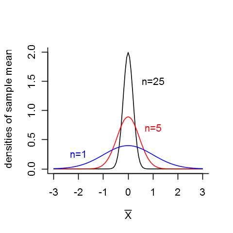

```r
options(repr.plot.width=4, repr.plot.height=4)
n <- 25; curve(dnorm(x, mean=0, sd=1/sqrt(n)), -3, 3,
              xlab=expression(bar(X)), ylab="densities of sample mean", bty="l")
n <-5; curve(dnorm(x, 0,1/sqrt(n)), col="red", add=TRUE)
n <-1; curve(dnorm(x, 0,1/sqrt(n)), col="blue",add=TRUE)
text(1, 1.5, "n=25")
text(1,0.7, "n=5", col="red")
text(-2, 0.25, "n=1", col="blue")
```

X 라는 확률 변수는 평균이 0이고 표준 편차가 1인 모집단 분포를 따릅니다.

모집단에서 원소 다섯 개를 뽑아서 표본들을 구성해 보겠습니다. 표본은 각각 sample 1, sample 2,...,sample n 이라고 하겠습니다.

각 표본의 표본 평균은 $\bar{sample_1}$, $\bar{sample_2}$,...,$\bar{sample_n}$일 것입니다. 그러니까 이 표본 평균들의 평균(혹은 기대치)은 아까 살펴본 대로 E[$\bar{X}$] = $\mu$, 곧 모집단의 평균 0 입니다. 이 표본 평균들의 표준 편차는 역시나 설명한 대로 $\frac{\sigma}{\sqrt{n}}$, 여기서는 $\frac{1}{\sqrt{5}}$입니다. R 코드에도 1/sqrt(n) 이라고 나와있습니다.

그러면 크기가 5인 표본의 표본 평균 $\bar{sample}$은 -$\infty$ 부터 $\infty$ 까지의 값을 가질 수 있지만, -1 부터 1 까지의 값들이 밀도가 높으며, 특히 0 근처의 값들이 밀도가 가장 높습니다. 이는 붉은 선으로 표시되어 있습니다.

이제 모집단에서 원소 스물 다섯 개를 뽑아서 표본들을 구성해 보겠습니다. 마찬가지로 표본을 각각 sample 1, sample 2,...,sample n 이라고 하겠습니다.

이것이 곧 표본의 n 을 키울 수록 표본의 평균이 모집단의 평균에 가까워져 가는 현상을 **대수의 법칙 the law of large numbers** 라고 합니다.

### 5.3.2 Nonnormal parent population

**중심 극한 정리 the central limit theorem**은 평균이 $\mu$ 이고 표준 편차가 $\sigma$인 어떠한 모집단(이제는 이 모집단이 정규분포를 따르지 않을 수도 있다고 가정합니다)에 대해서도, 표본 평균의 표집 분포(**sampling distribution** / 표본 분포라고 해석하는 sample distribution 과는 엄연히 다른 개념입니다!!)는 n(표본의 크기)이 충분히 클 때 다음을 만족합니다.

$$P(\frac{\bar{X}-\mu}{\sigma/\sqrt{n}} <= b) ~is ~approximately ~equal ~to ~P(Z <= b)$$

여기서 Z는 표준 정규 확률 변수입니다. 다시 말해, 표본 평균들을 표준화(standardize) 시킨 분포는 표준 정규 분포와 거의 같다는 의미입니다. 이런 것을 두고 $\bar{X}$가 *asymptotically normal* 이라고 표현합니다.

normal이 아닌 exponential distribution을 가지고 중심 극한 정리를 설명합니다.

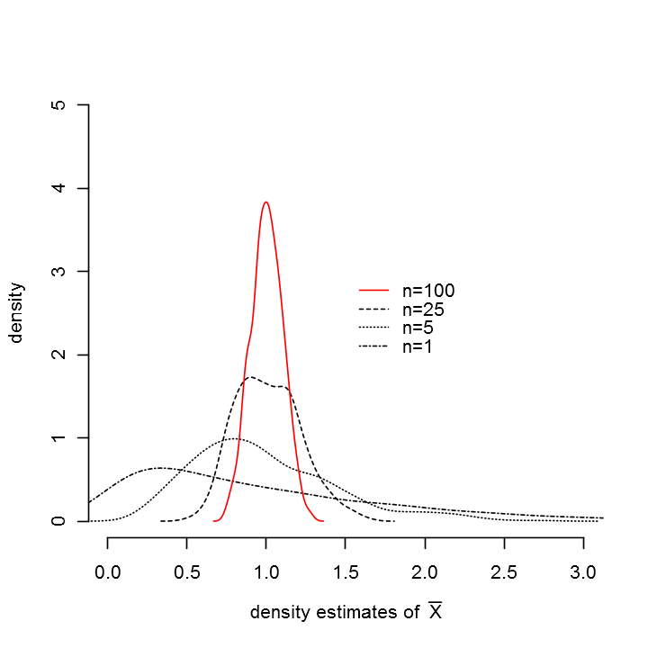

```r
options(repr.plot.width=6, repr.plot.height=6)
plot(0,0,type="n",xlim=c(0,3),ylim=c(0,5),
     xlab=expression("density estimates of "~bar(X)),
     bty="n", ylab="density")
m <- 500
res.5 <- c()
res.25 <- c()
res.100 <- c()
res.1 <-c()
for(i in 1:m)
    {
    res.1[i] <- mean(rexp(1,1))
    res.5[i] <- mean(rexp(5,1))
    res.25[i] <- mean(rexp(25,1))
    res.100[i] <- mean(rexp(100,1))
}
lines(density(res.1), lty=4)
lines(density(res.5), lty=3)
lines(density(res.25), lty=2)
lines(density(res.100), lty=1, col="red")
legend(1.5,3,legend=c("n=100", "n=25", "n=5", "n=1"),
       lty=1:4, col = c("red", "black", "black", "black"),bty="n")
```

빨간색 실선은 n = 100인 표본 평균의 표집분포입니다. 모집단의 rate parameter, $\lambda$는 1입니다. n = 25, n = 5 일 경우와 비교해서 분포 함수의 개형이 정규 분포 형태와 유사해지는 것을 확인할 수 있습니다. Exponential random variable의 경우, 평균은 $\lambda$ 라고 했으므로, 빨간 실선으로 나타낸 표집분포 역시 평균이 1에 가까워지는 것을 확인할 수 있습니다.

[Example 5.10] 이항 분포의 정규 근사

책의 인쇄 상태가 좀 이상해서, 그냥 간단하게 설명하겠습니다.

이항 분포의 경우, n이 크면 손으로 계산하기가 굉장히 복잡해집니다. 그래서 n이 크고, 성공 확률 p가 아주 작지 않을 경우에는 정규분포에 근사해서 문제를 풀 수 있습니다 (제가 스터디 때 이 반대로 이야기 했던 것 같아서.. 혹시 그렇게 메모하신 분들께 죄송합니다).

근사에 대한 증명은 무척 복잡해서, 그냥 예시를 보이도록 하겠습니다.

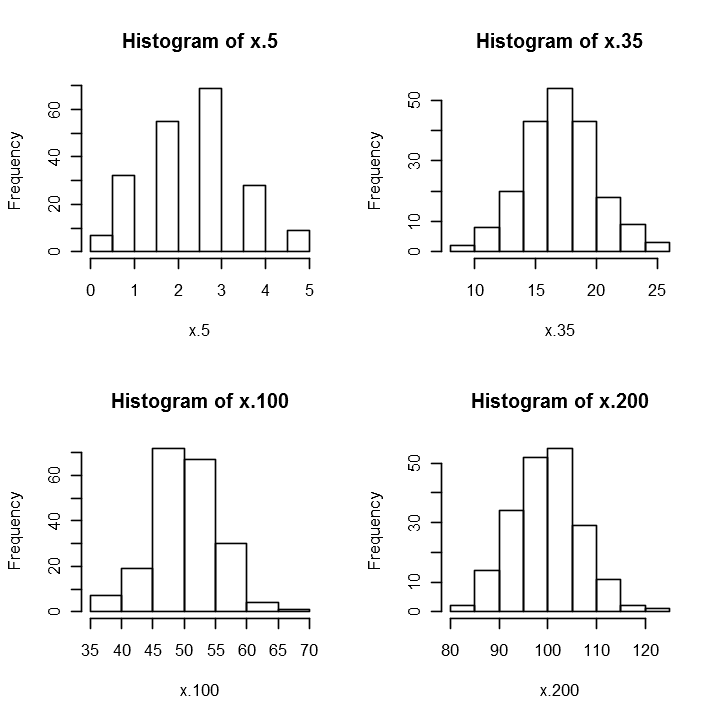

```r
x.5 <- rbinom(200, 5, 0.5)
x.35 <- rbinom(200, 35, 0.5)
x.100 <- rbinom(200, 100, 0.5)
x.200 <- rbinom(200, 200, 0.5)

par(mfrow=c(2,2))
hist(x.5)
hist(x.35)
hist(x.100)
hist(x.200)
```

그러면 n이 충분히 크고 X~Binomial(n,p) 일 때,

$$Z = \frac{X-E[X]}{\sqrt{Var[X]}} = \frac{X-np}{\sqrt{np(1-p)}}$$

의 분포는 근사적으로 표준정규분포 N(0,1)을 따른다.

[참고] 연속성 수정

근사치와 실제 확률 변수 값 간에 차이가 있기 때문에, 위의 식에서 Z를 계산할 때, X에 +/- 0.5를 해 주면 더욱 정확한 근사치를 얻을 수 있다.

예시) 어느 자동차 회사의 불량률이 0.2라고 한다. 이 회사 제품 50개를 조사하였을 때, 불량이 7개에서 14개 사이로 나올 확률을 구하시오. http://math7.tistory.com/50

- 평균 = np = 50 x 0.2 = 10; 분산 = np(1-p) = 50 x 0.2 x 0.8 = 8
- 우리가 알고 싶은 내용? **X = "불량의 개수" 일 때, P(7<= X <= 14)**
- X를 표준화 하여 Z로 만든다. 이 때 +/- 0.5를 해서 Z를 구하자.

P(7<= X <= 14)

= P($\frac{X-0.5-np}{\sqrt{np(1-p)}} <= Z <= \frac{X+0.5-np}{\sqrt{np(1-p)}}$)

= P($\frac{7-0.5-10}{\sqrt{8}} <= Z <= \frac{14+0.5-10}{\sqrt{8}}$)

= P(-1.24 <= Z <= 1.59)

= P(Z <= 1.59) - P(Z <= -1.24)

= 0.836595